# What’s Hot?

November 12, 2016

## Questions

**Scraping:**

- How can I scrape historical data for time-series data?

**Data:**

- What subreddits produce the most front-page content?
- What are people talking about on Reddit?
- When is the best time to submit content?

## Data

[The Wayback Machine](https://archive.org/web/) is a site that allows us to browse historical snapshots of any websites crawled by the site.

I [scraped](https://raw.githubusercontent.com/nycdatasci/bootcamp007_project/master/Project3-WebScraping/ReganYee/Wayback/wayback.csv) ~211k rows of data about the top 10 Reddit posts from 06/30/2016 - 11/11/2016:

```r
colnames(reddit)
```

```
##  [1] "snapshot_time"     "url"               "rank"
##  [4] "submit_datetime"   "snapshot_date"     "titles"
##  [7] "comments"          "submitter"         "upvotes"
## [10] "subreddit"         "snapshot_datetime" "submit_date"
## [13] "submit_hour"       "comments_num"      "comment_ratio"
```

Upvotes had data randomly imputed whenever there was an upvote value of '•'.  
Comments for threads which restricted comments had a value of 0 imputed.

## Scraping Workflow

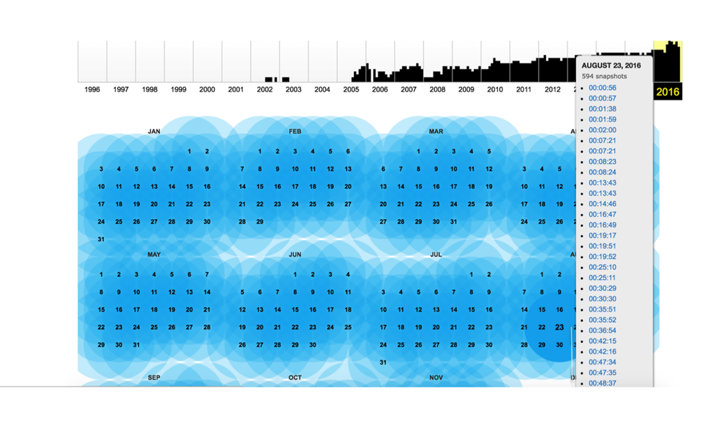

Findings

## Hottest Subreddits by Posts

[interactive chart not shown]

Only including subreddits with >= 10 posts in the top 10

## Comments vs Upvotes

|  | Titles | Subreddit | Ratio |
| --- | --- | --- | --- |
| 1 | [Breaking News] Donald Trump will be the 45th President of the United States | AskReddit | 13.236 |
| 2 | Game Thread: World Series Game 7 ⚾ Cubs (3-3) @ Indians (3-3) - 8:00 PM ET | baseball | 11.065 |
| 3 | Shots fired at Dallas protests | news | 6.7738 |
| 4 | What are the "Beats headphones" of your hobby? What makes you cringe to see others flexing? | AskReddit | 5.5952 |
| 5 | What do you have an extremely strong opinion on that is ultimately unimportant? | AskReddit | 5.57 |
| 6 | 'Shots fired' in Munich shopping centre | worldnews | 5.4604 |
| 7 | Reddit, of what food or drink can you almost not comprehend other people actually like? | AskReddit | 5.3611 |
| 8 | What costs more than it's worth? | AskReddit | 4.8042 |

## Hottest Upvote Time (by Date)

[interactive chart not shown]

## Hottest Upvote Time (by Snapshot Hr)

[interactive chart not shown]

## Hottest Upvote Time (by Submit Time)

[interactive chart not shown]

## Conclusions

- Reddit users gravitate towards r/funny, r/pics, r/gifs, r/todayilearned, r/aww, and r/gaming.
- r/AskReddit is the subreddit that generates the most discussion via the comments.
- There appears to be a positive trend in upvotes as the days go by in my dataset.
- The best time to submit content to Reddit to get the most amount of coverage is 13:00 - 19:00 UTC.
- The posts on reddit are most likely to have the most upvotes from 17:00 - 20:00 UTC.

## Retrospective

- Scraping Wayback Machine site is only good for sites which have enough snapshots per day.
- Website layouts change and hence need to be able to handle different tag name changes in the spider.
- Data became missing at random due to HTTP 429. Would like to find a way to try again for all the items that reach a 429 status.

Questions?